# Activity 6: Loading, Managing, Exploring Data, and Regression

MATH 340 Fall ’24

# A code-along!

### Make a project in RStudio and load the data

> 1. Create a new project in R.
> - Open RStudio.
> - Go to File -> New Project
> - Select ‘New Project’
> - Select ‘New Directory’
> - Select ‘New Project’
> - Enter name for project, and browse to where you want the new project folder to be located on your computer.
> - Click the ‘create project’ button.
> 2. Load the **gapminder** data (found on github).
> - Download the data as a .csv file from (https://github.com/mphitchman/survey). I’ll walk through this.
> - Move this csv file to your project folder.
> - Create a new script in R in which you load the **tidyverse** straightaway! (`library(tidyverse)`).
> - Load the data into your R session as a data frame called `df`. The code for doing this is `df = read.csv('filename.csv')` (enter the correct file name). Note this code will only load the data if your csv file is in your project folder.

### Familiarize yourself with the data

> 3. Take an initial look.
> 1. How many observations (rows) and how many variables (columns)?
> 2. What are the variable names, and what are the variable types (categorical or numeric)?
> 3. How many different countries are represented? Recall, `table()` gives a frequency distribution.
> 4. How many different years are in this data set?
> 5. How many different continents?

### Managing the Data (using *dplyr* data verbs!)

> 4. Filter the data to include just those observations for the most recent year available. Call this filtered data frame `df1`.

As an example, suppose we want to filter the data to include just a particular country, like Mexico. The following code, which uses the *dplyr* package (which is part of the *tidyverse*), does the trick:

```r
df %>% filter(country == "Mexico")
```

```
##    country continent year lifeExp       pop gdpPercap
## 1   Mexico  Americas 1952  50.789  30144317  3478.126
## 2   Mexico  Americas 1957  55.190  35015548  4131.547
## 3   Mexico  Americas 1962  58.299  41121485  4581.609
## 4   Mexico  Americas 1967  60.110  47995559  5754.734
## 5   Mexico  Americas 1972  62.361  55984294  6809.407
## 6   Mexico  Americas 1977  65.032  63759976  7674.929
## 7   Mexico  Americas 1982  67.405  71640904  9611.148
## 8   Mexico  Americas 1987  69.498  80122492  8688.156
## 9   Mexico  Americas 1992  71.455  88111030  9472.384
## 10  Mexico  Americas 1997  73.670  95895146  9767.298
## 11  Mexico  Americas 2002  74.902 102479927 10742.441
## 12  Mexico  Americas 2007  76.195 108700891 11977.575
```

**PRO TIP**: Display a table in a nicer format using the package **kableExtra** (which is loaded in this markdown file on line 47). This package has many bells and whistles for table formatting. See [kableExtra documentation](https://cran.r-project.org/web/packages/kableExtra/vignettes/awesome_table_in_html.html)

```r
df_Mexico = df %>% filter(country=='Mexico') %>% select(-continent)
kable(df_Mexico,
      col.names = c("country","year","life expectancy",
                    "population","per capita GDP") #customize column names for display
      ) %>%
  kable_classic()
```

| country | year | life expectancy | population | per capita GDP |
| --- | --- | --- | --- | --- |
| Mexico | 1952 | 50.789 | 30144317 | 3478.126 |
| Mexico | 1957 | 55.190 | 35015548 | 4131.547 |
| Mexico | 1962 | 58.299 | 41121485 | 4581.609 |
| Mexico | 1967 | 60.110 | 47995559 | 5754.734 |
| Mexico | 1972 | 62.361 | 55984294 | 6809.407 |
| Mexico | 1977 | 65.032 | 63759976 | 7674.929 |
| Mexico | 1982 | 67.405 | 71640904 | 9611.148 |
| Mexico | 1987 | 69.498 | 80122492 | 8688.156 |
| Mexico | 1992 | 71.455 | 88111030 | 9472.384 |
| Mexico | 1997 | 73.670 | 95895146 | 9767.298 |
| Mexico | 2002 | 74.902 | 102479927 | 10742.441 |
| Mexico | 2007 | 76.195 | 108700891 | 11977.575 |

Or, filter just those countries in 1992 with a life expectancy under 45 years of age. Display just the ‘country’, ‘continent’,and ‘lifeExp’ variables, and sort in ascending order by life expectancy.

```r
df %>%
  filter((year == 1992)&(lifeExp<45)) %>%
  select(country, continent, lifeExp) %>%
  arrange(lifeExp)
```

```
##         country continent lifeExp
## 1        Rwanda    Africa  23.599
## 2  Sierra Leone    Africa  38.333
## 3       Somalia    Africa  39.658
## 4        Angola    Africa  40.647
## 5       Liberia    Africa  40.802
## 6   Afghanistan      Asia  41.674
## 7 Guinea-Bissau    Africa  43.266
## 8    Mozambique    Africa  44.284
## 9       Burundi    Africa  44.736
```

See [intro to dplyr](https://mphitchman.com/stats/datamanip.html#Intro_to_dplyr) for more data management verbs using *dplyr*.

> 5. Focusing on just 2007, compute the average life expectancy of the countries by continent. That is, find the average life expectancy for all European countries, teh average of all African countries, etc.

To answer this question, use the `group_by()` command in *dplyr*.

For instance, if we want the total overall population for each year in the data set (and express these populations in units billions of people) we could do the following:

```r
df %>%
  group_by(year) %>%
  summarize(total_pop = round(sum(pop)/10^9,3))
```

```
## # A tibble: 12 × 2
##     year total_pop
##    <int>     <dbl>
##  1  1952      2.41
##  2  1957      2.66
##  3  1962      2.9
##  4  1967      3.22
##  5  1972      3.58
##  6  1977      3.93
##  7  1982      4.29
##  8  1987      4.69
##  9  1992      5.11
## 10  1997      5.52
## 11  2002      5.89
## 12  2007      6.25
```

Or, we could compute the total population by continent in the first year (1952) and the last year (2007) (in units millions of people), and sort by continent.

```r
df %>%
  filter(year %in% c(1952,2007)) %>%
  group_by(year,continent) %>%
  summarize(count = n(),
            total = sum(pop/10^6),
            mean = mean(pop/10^6),
            median = median(pop/10^6)) %>%
  arrange(continent)
```

```
## # A tibble: 10 × 6
## # Groups:   year [2]
##     year continent count  total   mean median
##    <int> <chr>     <int>  <dbl>  <dbl>  <dbl>
##  1  1952 Africa       52  238.    4.57   2.67
##  2  2007 Africa       52  930.   17.9   10.1
##  3  1952 Americas     25  345.   13.8    3.15
##  4  2007 Americas     25  899.   36.0    9.32
##  5  1952 Asia         33 1395.   42.3    7.98
##  6  2007 Asia         33 3812.  116.    24.8
##  7  1952 Europe       30  418.   13.9    7.20
##  8  2007 Europe       30  586.   19.5    9.49
##  9  1952 Oceania       2   10.7   5.34   5.34
## 10  2007 Oceania       2   24.5  12.3   12.3
```

> 6. Hey Hitchman, make side-by-side boxplots of life expectancy in 2007 grouped by continent.

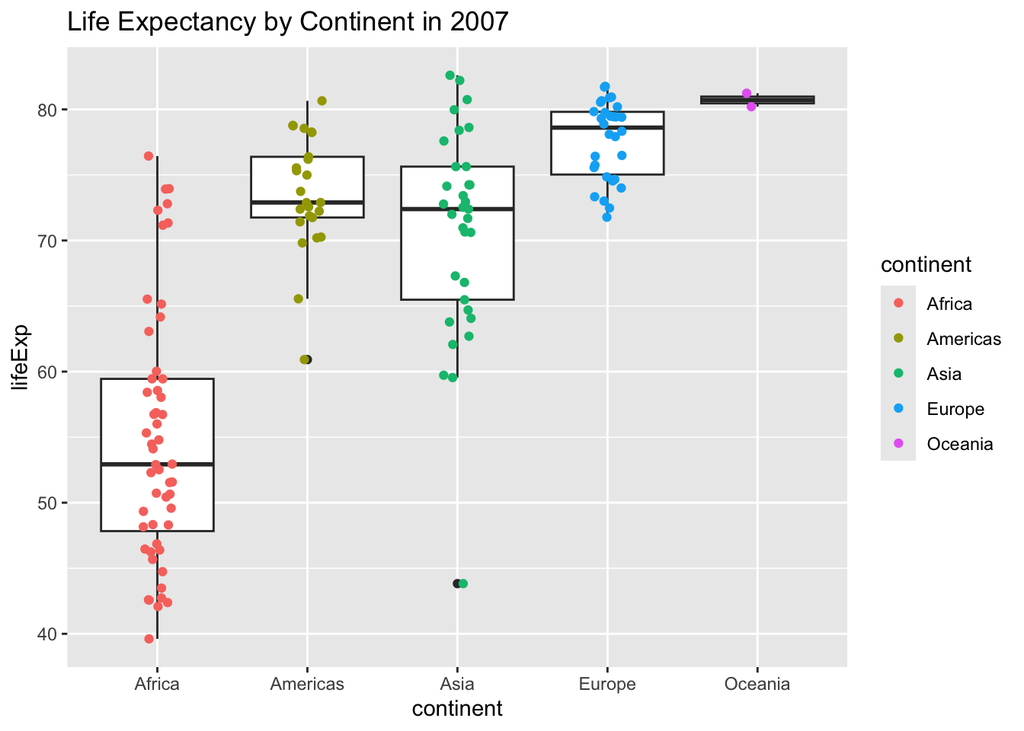

```r
ggplot(df %>% filter(year == 2007),
       aes(y=lifeExp,x=continent))+
  geom_boxplot()+
  geom_jitter(aes(col=continent),width=.1)+
  ggtitle('Life Expectancy by Continent in 2007')
```

### Run a regression model

> 7. Are life expectancy and per capita GDP associated in 2007? Make a scatter plot to qualitatively assess this question. Consider adding color to the dots that identifies the country’s continent.
> 8. Build the least squares linear model to predict life expectancy in a country from its per capita GDP. - What is the equation of the least-squares regression line?
> - Make a residual plot. Does there appear to be constant variance in this linear model?
> - Make a histogram of the residuals. Is it reasonable to assume the residuals are normally distributed?
> - What is $r^2$?
> - What is good about this model? How can it be improved?

### Now you try.

> From the gapminder site (https://www.gapminder.org/data/) download **as a csv file** one data set of interest to you. Load the data into your R session, explore it, and share something you found interesting (some suggetsions: pictures are nice, summary statistics are nice, tables are nice, text explanations are nice, results of inference are nice).